# WRANGLE ACT ON WERATEDOGS DATA *BY AMOS OMOFAIYE*

## Now I will assess the image predictions dataset stored in di dataframe

```python
# Assesing the shape of the di dataframe.
di.shape
```

```
(2075, 12)
```

```python
# Viewing some samples of the dataframe
di.sample(5,replace=False)
```

|  | tweet_id | jpg_url | img_num | p1 | p1_conf | p1_dog | p2 | p2_conf | p2_dog | p3 | p3_conf | p3_dog |
| --- | --- | --- | --- | --- | --- | --- | --- | --- | --- | --- | --- | --- |
| 1567 | 794205286408003585 | https://pbs.twimg.com/media/CwWVe_3WEAAHAvx.jpg | 3 | pedestal | 0.662660 | False | fountain | 0.294827 | False | brass | 0.020371 | False |
| 1895 | 850019790995546112 | https://pbs.twimg.com/media/C8vgfTsXgAA561h.jpg | 3 | Shetland_sheepdog | 0.759907 | True | collie | 0.107405 | True | Pembroke | 0.052335 | True |
| 318 | 671763349865160704 | https://pbs.twimg.com/media/CVKVM3NW4AAdi1e.jpg | 1 | prayer_rug | 0.445334 | False | doormat | 0.275311 | False | bib | 0.048813 | False |
| 218 | 670073503555706880 | https://pbs.twimg.com/media/CUyUSuWXIAAZKYF.jpg | 1 | malamute | 0.601886 | True | Siberian_husky | 0.340106 | True | Eskimo_dog | 0.050041 | True |
| 1126 | 727524757080539137 | https://pbs.twimg.com/media/Chiv6BAW4AAiQvH.jpg | 2 | Pomeranian | 0.958834 | True | Chihuahua | 0.024099 | True | chow | 0.003941 | True |

```python
# Listing out the columns of the di dataframe
column_lister(di)
```

```
0 tweet_id
1 jpg_url
2 img_num
3 p1
4 p1_conf
5 p1_dog
6 p2
7 p2_conf
8 p2_dog
9 p3
10 p3_conf
11 p3_dog
```

### image predictions (di) dataframe columns

> At this juncture, I will explain these columns in brief. Please note that some of the columns in this dataset are generated from an image prediction software.
> - tweet_id is the id of each tweet. This should be unique.
> - jpg_url is the uniform resource locator of the image of the dog being tweeted about
> - img_num captures the specific image number from a list of possible images depicted by numbers.
> - p1 is the algorithm's first prediction for the image in the tweet.
> - p1_conf captures how confident the algorithm is in the first prediction.
> - p1_dog captures whether the first prediction is a breed of dog or not.
> - p2 is the algorithm's most likely second prediction for the image in the tweet.
> - p2_config captures how confident the algorithm is in the second prediction.
> - p2_dog captures whether the second prediction is a breed of dog or not.
> - p3 is the algorithm's most likely third prediction for the image in the tweet.
> - p3_config captures how confident the algorithm is in the third prediction.
> - p3_dog captures whether the third prediction is a breed of dog or not.

```python
# Customarily, I want to check the tweet_id for uniqueness since it will be needed in joining the three data sets.
# To be useful for joinig it
# must be uniquely present in all the three dataframes.
di.tweet_id.unique().size, di.tweet_id.nunique()
```

```
(2075, 2075)
```

```python
# Checking for null values
di.info()
# There are no null values in this dataset. Let's continue.
```

```
<class 'pandas.core.frame.DataFrame'>
RangeIndex: 2075 entries, 0 to 2074
Data columns (total 12 columns):
 #   Column    Non-Null Count  Dtype
---  ------    --------------  -----
 0   tweet_id  2075 non-null   int64
 1   jpg_url   2075 non-null   object
 2   img_num   2075 non-null   int64
 3   p1        2075 non-null   object
 4   p1_conf   2075 non-null   float64
 5   p1_dog    2075 non-null   bool
 6   p2        2075 non-null   object
 7   p2_conf   2075 non-null   float64
 8   p2_dog    2075 non-null   bool
 9   p3        2075 non-null   object
 10  p3_conf   2075 non-null   float64
 11  p3_dog    2075 non-null   bool
dtypes: bool(3), float64(3), int64(2), object(4)
memory usage: 152.1+ KB
```

```python
# Describing the numerical variables
di.describe()
# It appears 75% of the images are 1.
```

|  | tweet_id | img_num | p1_conf | p2_conf | p3_conf |
| --- | --- | --- | --- | --- | --- |
| count | 2.075000e+03 | 2075.000000 | 2075.000000 | 2.075000e+03 | 2.075000e+03 |
| mean | 7.384514e+17 | 1.203855 | 0.594548 | 1.345886e-01 | 6.032417e-02 |
| std | 6.785203e+16 | 0.561875 | 0.271174 | 1.006657e-01 | 5.090593e-02 |
| min | 6.660209e+17 | 1.000000 | 0.044333 | 1.011300e-08 | 1.740170e-10 |
| 25% | 6.764835e+17 | 1.000000 | 0.364412 | 5.388625e-02 | 1.622240e-02 |
| 50% | 7.119988e+17 | 1.000000 | 0.588230 | 1.181810e-01 | 4.944380e-02 |
| 75% | 7.932034e+17 | 1.000000 | 0.843855 | 1.955655e-01 | 9.180755e-02 |
| max | 8.924206e+17 | 4.000000 | 1.000000 | 4.880140e-01 | 2.734190e-01 |

```python
# Checking for duplicates
sum(di.duplicated())
```

```
0
```

## Issues

### Tidiness Issues

> The identified tidiness issues are listed below.
> 1. The created_at column of the dj(twitter-json) dataframe and the timestamp column of the dt dataframe contain three different variables namely Day of the week, Month of the year, and time. These components should be in different columns since they are different variables.
> 2. In the dt dataframe, the four columns namely doggo, floofer, pupper, and puppo all captures a stage of dog. Since a dog is expected to belong to only one of these stages, only one variable is needed to capture them not four.
> 3. In the dt dataframe, there should be a column to capture actual dog rating (that is a standardized dog rating)
> 4. Since all the three datasets contain related information and have the same unique identifier (tweet_id), they should be in the same sheet (dataframe). So, it will be necessary to combine them although some values will be lost because they don't have equal size.

> Now let us proceed to addressing these quality and tidiness issues.

## Cleaning the assessed data

>

> This cleaning effort will address only the issues identified above. Cleaning shall proceed in the order dj, to dt, and then di. This was the order of assessing. Also, I will first tackle completeness issues (missing data issues), then the tidiness issues, and finally address the remaining data quality issues for each data frame. Shall we? Of course, we shall!

```python
# To begin I will make a copy of all my dataframes.
dj_clean = dj.copy()
dt_clean = dt.copy()
di_clean = di.copy()
# I will follow the Define, Code, and Test format.
```

### Cleaning1 : Fixing missing data and extraneous variables in the dj_clean dataframe

#### Define: Drop the retweeted column because it contains only false values and therefore does not vary.

>

#### Code

```python
#dj_clean.columns
# Dropping the retweeted column
dj_clean.drop('retweeted', axis=1, inplace=True)
```

#### Test

```python
# Testing to see the effect of the code
dj_clean.columns
```

```
Index(['tweet_id', 'created_at', 'retweet_count', 'favorite_count',
       'full_text', 'favorited'],
      dtype='object')
```

### Cleaning 2: Removing Missing Values (NaNs) and unneeded columns in dt_clean dataframe

> It is a requirement of this project that only original tweets should be used.Therefore, the values in retweeted_status_id, retweeted_status_timestamp, retweeted_status_user_id, in_reply_to_status_id, in_reply_to_user_id should not be used in analysis.

#### Define:

> 1. Remove the non-null values in the following columns: retweeted_status_id, retweeted_status_timestamp, retweeted_status_user_id, in_reply_to_status_id, in_reply_to_user_id.
> 2. Thereafter, drop the columns.

> Please note that the columns could have just been dropped without the first part but the project requires it.

#### Code

```python
# Checking before coding
dt_clean.info()
```

```
<class 'pandas.core.frame.DataFrame'>
RangeIndex: 2356 entries, 0 to 2355
Data columns (total 17 columns):
 #   Column                      Non-Null Count  Dtype
---  ------                      --------------  -----
 0   tweet_id                    2356 non-null   int64
 1   in_reply_to_status_id       78 non-null     float64
 2   in_reply_to_user_id         78 non-null     float64
 3   timestamp                   2356 non-null   object
 4   source                      2356 non-null   object
 5   text                        2356 non-null   object
 6   retweeted_status_id         181 non-null    float64
 7   retweeted_status_user_id    181 non-null    float64
 8   retweeted_status_timestamp  181 non-null    object
 9   expanded_urls               2297 non-null   object
 10  rating_numerator            2356 non-null   int64
 11  rating_denominator          2356 non-null   int64
 12  name                        2356 non-null   object
 13  doggo                       2356 non-null   object
 14  floofer                     2356 non-null   object
 15  pupper                      2356 non-null   object
 16  puppo                       2356 non-null   object
dtypes: float64(4), int64(3), object(10)
memory usage: 313.0+ KB
```

```python
# Removing the non null values in in_reply_to_status_id, in_reply_to_user_id
# Here, I will use the tilda ~ shortcut. This is like the not operator.
# First, I will gather such values
reply = (~dt_clean.in_reply_to_status_id.isnull())
reply.sum() # This as expected is 78
# Second, I will remove the gathered values from the dataframe.
dt_clean = dt_clean[~reply]
dt_clean.info()
```

```
<class 'pandas.core.frame.DataFrame'>
Int64Index: 2278 entries, 0 to 2355
Data columns (total 17 columns):
 #   Column                      Non-Null Count  Dtype
---  ------                      --------------  -----
 0   tweet_id                    2278 non-null   int64
 1   in_reply_to_status_id       0 non-null      float64
 2   in_reply_to_user_id         0 non-null      float64
 3   timestamp                   2278 non-null   object
 4   source                      2278 non-null   object
 5   text                        2278 non-null   object
 6   retweeted_status_id         181 non-null    float64
 7   retweeted_status_user_id    181 non-null    float64
 8   retweeted_status_timestamp  181 non-null    object
 9   expanded_urls               2274 non-null   object
 10  rating_numerator            2278 non-null   int64
 11  rating_denominator          2278 non-null   int64
 12  name                        2278 non-null   object
 13  doggo                       2278 non-null   object
 14  floofer                     2278 non-null   object
 15  pupper                      2278 non-null   object
 16  puppo                       2278 non-null   object
dtypes: float64(4), int64(3), object(10)
memory usage: 320.3+ KB
```

```python
# Removing the non null values in retweeted_status_id, retweeted_status_timestamp, retweeted_status_user_id
# Here, I will use the tilda ~ shortcut. This is like the not operator.
# First, I will gather such values
retweet = (~dt_clean.retweeted_status_id.isnull())
retweet.sum() # This as expected is 181
# Second, I will remove the gathered values from the dataframe.
dt_clean = dt_clean[~retweet]
# To see the effect of the code
dt_clean.info()
```

```
<class 'pandas.core.frame.DataFrame'>
Int64Index: 2097 entries, 0 to 2355
Data columns (total 17 columns):
 #   Column                      Non-Null Count  Dtype
---  ------                      --------------  -----
 0   tweet_id                    2097 non-null   int64
 1   in_reply_to_status_id       0 non-null      float64
 2   in_reply_to_user_id         0 non-null      float64
 3   timestamp                   2097 non-null   object
 4   source                      2097 non-null   object
 5   text                        2097 non-null   object
 6   retweeted_status_id         0 non-null      float64
 7   retweeted_status_user_id    0 non-null      float64
 8   retweeted_status_timestamp  0 non-null      object
 9   expanded_urls               2094 non-null   object
 10  rating_numerator            2097 non-null   int64
 11  rating_denominator          2097 non-null   int64
 12  name                        2097 non-null   object
 13  doggo                       2097 non-null   object
 14  floofer                     2097 non-null   object
 15  pupper                      2097 non-null   object
 16  puppo                       2097 non-null   object
dtypes: float64(4), int64(3), object(10)
memory usage: 294.9+ KB
```

```python
# Next, I will remove the columns
dt_clean.drop(['in_reply_to_status_id',
                    'in_reply_to_user_id',
                    'retweeted_status_id',
                    'retweeted_status_user_id',
                    'retweeted_status_timestamp'], axis=1, inplace=True)
```

#### Test

```python
# Checking to see that retweeted_status_id, retweeted_status_timestamp,
# retweeted_status_user_id, in_reply_to_status_id, in_reply_to_user_id no longer exist in the dt_clean dataframe.
dt_clean.info()
```

```
<class 'pandas.core.frame.DataFrame'>
Int64Index: 2097 entries, 0 to 2355
Data columns (total 12 columns):
 #   Column              Non-Null Count  Dtype
---  ------              --------------  -----
 0   tweet_id            2097 non-null   int64
 1   timestamp           2097 non-null   object
 2   source              2097 non-null   object
 3   text                2097 non-null   object
 4   expanded_urls       2094 non-null   object
 5   rating_numerator    2097 non-null   int64
 6   rating_denominator  2097 non-null   int64
 7   name                2097 non-null   object
 8   doggo               2097 non-null   object
 9   floofer             2097 non-null   object
 10  pupper              2097 non-null   object
 11  puppo               2097 non-null   object
dtypes: int64(3), object(9)
memory usage: 213.0+ KB
```

### Cleaning 3: Changing names in dt_clean and di_clean to title

#### Define:

1. In the dt_clean dataframe, change name values to title case. This includes name, doggo, floofer, pupper, and puppo
2. In the di_clean dataframe, change the values in p1,p2,p3 to title case

#### Code

```python
# Before the change
#dt_clean.name.value_counts()
#di_clean.p1.value_counts()
#di_clean.p2.value_counts()
#di_clean.p3.value_counts()
```

```python
# Now, shall we?
dt_clean['name'] = [name.capitalize() for name in dt_clean['name']]
dt_clean['doggo'] = [doggo.capitalize() for doggo in dt_clean['doggo']]
dt_clean['floofer'] = [floofer.capitalize() for floofer in dt_clean['floofer']]
dt_clean['pupper'] = [pupper.capitalize() for pupper in dt_clean['pupper']]
dt_clean['puppo'] = [puppo.capitalize() for puppo in dt_clean['puppo']]
#dt_clean.name.value_counts()
di_clean['p1'] = [p1.capitalize() for p1 in di_clean['p1']]
di_clean['p2'] = [p2.capitalize() for p2 in di_clean['p2']]
di_clean['p3'] = [p3.capitalize() for p3 in di_clean['p3']]
di_clean['p3'].value_counts()
```

```
Labrador_retriever    79
Chihuahua             58
Golden_retriever      48
Eskimo_dog            38
Kelpie                35
                      ..
Pier                   1
Pickup                 1
Valley                 1
Kerry_blue_terrier     1
Pot                    1
Name: p3, Length: 408, dtype: int64
```

#### Test

```python
# Checking to see that all names in dt_clean and di_clean are now capitalized. This concerns name, p1, p2, and p3.
dt_clean.name.value_counts()
dt_clean.doggo.value_counts()
dt_clean.floofer.value_counts()
dt_clean.pupper.value_counts()
dt_clean.puppo.value_counts()
di_clean.p1.value_counts()
di_clean.p2.value_counts()
di_clean.p3.value_counts()
```

```
Labrador_retriever    79
Chihuahua             58
Golden_retriever      48
Eskimo_dog            38
Kelpie                35
                      ..
Pier                   1
Pickup                 1
Valley                 1
Kerry_blue_terrier     1
Pot                    1
Name: p3, Length: 408, dtype: int64
```

### Cleaning 4: Dealing with None and Combining dog stages to one column

#### Define:

1. In the dt_clean dataframe, replace None in the name and dog stages columns with a blank.
2. Thereafter, combine the dog stages to one column and drop the original dog stages columns and columns with more than one dog_stage.
3. Finally, fill all nulls with 'Not_available'. Do this also for the nulls in name.
4. Leave the remaining names intact since I don't know what to replace them with.

#### Code

```python
# Before the change
dt_clean.name.value_counts()
```

```
None        603
A            55
Lucy         11
Charlie      11
Cooper       10
           ...
Leonidas      1
Fido          1
Chevy         1
Champ         1
Tango         1
Name: name, Length: 955, dtype: int64
```

```python
# Replacing None with blank
dt_clean.name.replace('None', '', inplace=True)
dt_clean.doggo.replace('None', '', inplace=True)
dt_clean.floofer.replace('None', '', inplace=True)
dt_clean.pupper.replace('None', '', inplace=True)
dt_clean.puppo.replace('None', '', inplace=True)
```

```python
# Test for the effect
#dt_clean.name.value_counts()
#dt_clean.sample(20, replace=False) # Change effected.
```

```python
# combining the dog stages column and separating those with
dt_clean['dog_stage'] = dt_clean[['doggo', 'floofer', 'pupper', 'puppo']].agg(''.join, axis=1)
dt_clean.dog_stage.replace('', 'Not_available', inplace=True)
dt_clean.dog_stage.value_counts()
```

```
Not_available    1761
Pupper            221
Doggo              72
Puppo              23
Floofer             9
DoggoPupper         9
DoggoPuppo          1
DoggoFloofer        1
Name: dog_stage, dtype: int64
```

```python
# Dropping dog_stage values with  more than one dog_stages
dt_clean.drop(dt_clean[dt_clean.dog_stage=='DoggoPupper'].index,inplace=True)
dt_clean.drop(dt_clean[dt_clean.dog_stage=='DoggoPuppo'].index,inplace=True)
dt_clean.drop(dt_clean[dt_clean.dog_stage=='DoggoFloofer'].index,inplace=True)
```

```python
# Checking to see the effect
dt_clean.dog_stage.value_counts()
```

```
Not_available    1761
Pupper            221
Doggo              72
Puppo              23
Floofer             9
Name: dog_stage, dtype: int64
```

```python
# Dropping the original dog stages columns
dt_clean.head(0)
dt_clean.drop(['doggo','floofer','pupper','puppo'], axis=1, inplace=True)
dt_clean.head(0)
```

|  | tweet_id | timestamp | source | text | expanded_urls | rating_numerator | rating_denominator | name | dog_stage |
| --- | --- | --- | --- | --- | --- | --- | --- | --- | --- |

```python
# Replacing blanks in name with 'Not_Available'
dt_clean.name.replace('', 'Not_Available', inplace=True)
dt_clean.name.value_counts()
```

```
Not_Available    597
A                 55
Charlie           11
Lucy              11
Oliver            10
                ...
Chevy              1
Champ              1
Chaz               1
Ashleigh           1
Tango              1
Name: name, Length: 952, dtype: int64
```

#### Test

```python
# Using samples to check for the effects
dt_clean.sample(5, replace=False)
```

|  | tweet_id | timestamp | source | text | expanded_urls | rating_numerator | rating_denominator | name | dog_stage |
| --- | --- | --- | --- | --- | --- | --- | --- | --- | --- |
| 2123 | 670385711116361728 | 2015-11-27 23:36:23 +0000 | <a href="http://twitter.com/download/iphone" r... | Meet Larry. He's a Panoramic Benzoate. Can sho... | https://twitter.com/dog_rates/status/670385711... | 8 | 10 | Larry | Not_available |
| 112 | 870804317367881728 | 2017-06-03 00:48:22 +0000 | <a href="http://twitter.com/download/iphone" r... | Real funny guys. Sending in a pic without a do... | https://twitter.com/dog_rates/status/870804317... | 11 | 10 | Not_Available | Not_available |
| 1878 | 675047298674663426 | 2015-12-10 20:19:52 +0000 | <a href="http://twitter.com/download/iphone" r... | This is a fluffy albino Bacardi Columbia mix. ... | https://twitter.com/dog_rates/status/675047298... | 11 | 10 | A | Not_available |
| 809 | 771500966810099713 | 2016-09-02 00:12:18 +0000 | <a href="http://twitter.com/download/iphone" r... | This is Dakota. He's just saying hi. That's al... | https://twitter.com/dog_rates/status/771500966... | 12 | 10 | Dakota | Not_available |
| 1999 | 672523490734551040 | 2015-12-03 21:11:09 +0000 | <a href="http://twitter.com/download/iphone" r... | When she says she'll be ready in a minute but ... | https://twitter.com/dog_rates/status/672523490... | 10 | 10 | Not_Available | Not_available |

### Cleaning 5: Splitting created_at column of the dj_clean and Merging the three datasets

#### Define:

1. Split the created_at column of dj_clean to month, day, and time.
2. Give dexcriptive names to the non-descriptive columns in di_clean (that is p1,p2,p3 and the others)
3. Merge the three dataframes into one dataframe named df_all

#### Code

```python
# Before splitting the created_at column of dj_clean
dj_clean.created_at.value_counts()
```

```
Thu Feb 25 19:04:13 +0000 2016    1
Thu Nov 26 22:16:09 +0000 2015    1
Tue Aug 30 23:58:40 +0000 2016    1
Sun Jul 17 01:05:25 +0000 2016    1
Mon Jan 25 02:17:57 +0000 2016    1
                                 ..
Wed Mar 30 15:34:51 +0000 2016    1
Wed Mar 09 03:45:22 +0000 2016    1
Wed Mar 09 22:24:31 +0000 2016    1
Wed Nov 25 17:49:14 +0000 2015    1
Wed Jun 01 23:52:28 +0000 2016    1
Name: created_at, Length: 2354, dtype: int64
```

```python
dt_clean.timestamp.value_counts()
```

```
2016-02-17 02:17:19 +0000    1
2017-02-09 01:27:41 +0000    1
2016-12-04 19:02:24 +0000    1
2016-09-26 17:29:48 +0000    1
2016-03-14 00:49:23 +0000    1
                            ..
2016-01-18 01:38:15 +0000    1
2017-07-11 00:00:02 +0000    1
2016-02-09 03:35:31 +0000    1
2016-10-03 15:42:44 +0000    1
2015-12-06 22:54:44 +0000    1
Name: timestamp, Length: 2086, dtype: int64
```

> Taking another look at the created_at column, I realized it is similar to the timestamp column of dt_clean. Moreover, the timestamp column is much cleaner and will be easier to work with with minimal code than the created_at column. Since I will later merge the dataframes, I will at this stage drop created_at column and focus on timestamp so as to guide against unnecessary duplication. Thanks for the inconvinience, if any.

```python
# Dropping the created_at column of dj_clean
dj_clean.drop('created_at', axis=1, inplace=True)
# Checking for the effect
dj_clean.head(0)
```

|  | tweet_id | retweet_count | favorite_count | full_text | favorited |
| --- | --- | --- | --- | --- | --- |

```python
# Convenverting timestamp of dt_clean to datetime datatype
# Checking before changing the data type
dt_clean.dtypes
dt_clean['timestamp'] = pd.to_datetime(dt_clean['timestamp'])
# Checking to see the effect
dt_clean.dtypes
```

```
tweet_id                            int64
timestamp             datetime64[ns, UTC]
source                             object
text                               object
expanded_urls                      object
rating_numerator                    int64
rating_denominator                  int64
name                               object
dog_stage                          object
dtype: object
```

```python
# Splitting the timestamp column
# Creating the year column
dt_clean['year'] = dt_clean['timestamp'].dt.year
# Creating the month column
dt_clean['month'] = dt_clean['timestamp'].dt.month
# Creating the day column
dt_clean['day'] = dt_clean['timestamp'].dt.day
# Creating the time column
dt_clean['time'] = dt_clean['timestamp'].dt.time
# Creating the week_day column to capture days in string
dt_clean['week_day'] = dt_clean['timestamp'].dt.dayofweek
days = {0:'Sun',1:'Mon',2:'Tues',3:'Weds',4:'Thurs',5:'Fri',6:'Sat'}
dt_clean['week_day'] = dt_clean['week_day'].apply(lambda x: days[x])
# Checking
dt_clean.head(2)
```

|  | tweet_id | timestamp | source | text | expanded_urls | rating_numerator | rating_denominator | name | dog_stage | year | month | day | time | week_day |
| --- | --- | --- | --- | --- | --- | --- | --- | --- | --- | --- | --- | --- | --- | --- |
| 0 | 892420643555336193 | 2017-08-01 16:23:56+00:00 | <a href="http://twitter.com/download/iphone" r... | This is Phineas. He's a mystical boy. Only eve... | https://twitter.com/dog_rates/status/892420643... | 13 | 10 | Phineas | Not_available | 2017 | 8 | 1 | 16:23:56 | Mon |
| 1 | 892177421306343426 | 2017-08-01 00:17:27+00:00 | <a href="http://twitter.com/download/iphone" r... | This is Tilly. She's just checking pup on you.... | https://twitter.com/dog_rates/status/892177421... | 13 | 10 | Tilly | Not_available | 2017 | 8 | 1 | 00:17:27 | Mon |

```python
# Creating year_month
dt_clean['year_month'] = dt_clean['timestamp'].dt.month
months = {1:'Jan',2:'Feb',3:'Mar',4:'Apr',5:'May',6:'Jun',7:'Jul',8:'Aug',9:'Sep',10:'Oct',11:'Nov',12:'Dec'}
dt_clean['year_month'] = dt_clean['year_month'].apply(lambda x: months[x])
dt_clean.head(1)
```

|  | tweet_id | timestamp | source | text | expanded_urls | rating_numerator | rating_denominator | name | dog_stage | year | month | day | time | week_day | year_month |
| --- | --- | --- | --- | --- | --- | --- | --- | --- | --- | --- | --- | --- | --- | --- | --- |
| 0 | 892420643555336193 | 2017-08-01 16:23:56+00:00 | <a href="http://twitter.com/download/iphone" r... | This is Phineas. He's a mystical boy. Only eve... | https://twitter.com/dog_rates/status/892420643... | 13 | 10 | Phineas | Not_available | 2017 | 8 | 1 | 16:23:56 | Mon | Aug |

```python
# Dropping dj_clean full_text column and renaming dt_clean text column to tweet
dj_clean.drop('full_text', axis=1,inplace=True)
dt_clean.rename(columns={'text':'tweet'}, inplace=True)
# Checking
dj_clean.head(1)
dt_clean.head(1)
```

|  | tweet_id | timestamp | source | tweet | expanded_urls | rating_numerator | rating_denominator | name | dog_stage | year | month | day | time | week_day | year_month |
| --- | --- | --- | --- | --- | --- | --- | --- | --- | --- | --- | --- | --- | --- | --- | --- |
| 0 | 892420643555336193 | 2017-08-01 16:23:56+00:00 | <a href="http://twitter.com/download/iphone" r... | This is Phineas. He's a mystical boy. Only eve... | https://twitter.com/dog_rates/status/892420643... | 13 | 10 | Phineas | Not_available | 2017 | 8 | 1 | 16:23:56 | Mon | Aug |

```python
# Now we give descriptive names to the variables in di_clean dataframe
di_clean.rename(columns={'p1':'predicted_image1',
                        'p2': 'predicted_image2',
                        'p3':'predicted_image3',
                        'p1_conf':'confidence_on_image1',
                        'p2_conf':'confidence_on_image2',
                        'p3_conf':'confidence_on_image3',
                        'p1_dog':'image1_dog?',
                        'p2_dog':'image2_dog?',
                        'p3_dog':'image3_dog?'}, inplace=True)
```

```python
# Checking to see change in the names
di_clean.head(1)
```

|  | tweet_id | jpg_url | img_num | predicted_image1 | confidence_on_image1 | image1_dog? | predicted_image2 | confidence_on_image2 | image2_dog? | predicted_image3 | confidence_on_image3 | image3_dog? |
| --- | --- | --- | --- | --- | --- | --- | --- | --- | --- | --- | --- | --- |
| 0 | 666020888022790149 | https://pbs.twimg.com/media/CT4udn0WwAA0aMy.jpg | 1 | Welsh_springer_spaniel | 0.465074 | True | Collie | 0.156665 | True | Shetland_sheepdog | 0.061428 | True |

```python
# Before combining on tweet_id, I want to check for equality in id and remove those id that are in one dataframe and not in
# the other
missing1 = (~dj_clean.tweet_id.isin(list(dt_clean.tweet_id)))
missing1.sum() # This is 268, we need to remove these.
dj_clean = dj_clean[~missing1]
```

```python
# Checking to see that they are equal in rows.
dt_clean.shape,dj_clean.shape
# Now merging the dt_clean and dj_clean dataframes to form df_all1
df_all1 = pd.merge(dt_clean, dj_clean, on='tweet_id', how = 'inner')
# Checking to see the effect
df_all1.head(2)
```

|  | tweet_id | timestamp | source | tweet | expanded_urls | rating_numerator | rating_denominator | name | dog_stage | year | month | day | time | week_day | year_month | retweet_count | favorite_count | favorited |
| --- | --- | --- | --- | --- | --- | --- | --- | --- | --- | --- | --- | --- | --- | --- | --- | --- | --- | --- |
| 0 | 892420643555336193 | 2017-08-01 16:23:56+00:00 | <a href="http://twitter.com/download/iphone" r... | This is Phineas. He's a mystical boy. Only eve... | https://twitter.com/dog_rates/status/892420643... | 13 | 10 | Phineas | Not_available | 2017 | 8 | 1 | 16:23:56 | Mon | Aug | 8853 | 39467 | False |
| 1 | 892177421306343426 | 2017-08-01 00:17:27+00:00 | <a href="http://twitter.com/download/iphone" r... | This is Tilly. She's just checking pup on you.... | https://twitter.com/dog_rates/status/892177421... | 13 | 10 | Tilly | Not_available | 2017 | 8 | 1 | 00:17:27 | Mon | Aug | 6514 | 33819 | False |

```python
# Next, I will merge df_all1 with di_clean to form df_all
# I want to check for id that are di_clean but not in df_all1
missing2 = (~di_clean.tweet_id.isin(list(df_all1.tweet_id)))
missing2.sum()
# This is a whopping 114
# Now I will remove them
di_clean = di_clean[~missing2]
# Checking
di_clean.shape,df_all1.shape # With what I have here, It is evident that we will lose some more data points
# because they are in only one of the dataframes that I want to merge. But I shall go ahead
# Now merging the di_clean and df_all1 dataframes to form df_all
df_all = pd.merge(df_all1, di_clean, on='tweet_id', how = 'inner')
# Checking to see the effect
df_all.head(2)
```

|  | tweet_id | timestamp | source | tweet | expanded_urls | rating_numerator | rating_denominator | name | dog_stage | year | ... | img_num | predicted_image1 | confidence_on_image1 | image1_dog? | predicted_image2 | confidence_on_image2 | image2_dog? | predicted_image3 | confidence_on_image3 | image3_dog? |
| --- | --- | --- | --- | --- | --- | --- | --- | --- | --- | --- | --- | --- | --- | --- | --- | --- | --- | --- | --- | --- | --- |
| 0 | 892420643555336193 | 2017-08-01 16:23:56+00:00 | <a href="http://twitter.com/download/iphone" r... | This is Phineas. He's a mystical boy. Only eve... | https://twitter.com/dog_rates/status/892420643... | 13 | 10 | Phineas | Not_available | 2017 | ... | 1 | Orange | 0.097049 | False | Bagel | 0.085851 | False | Banana | 0.076110 | False |
| 1 | 892177421306343426 | 2017-08-01 00:17:27+00:00 | <a href="http://twitter.com/download/iphone" r... | This is Tilly. She's just checking pup on you.... | https://twitter.com/dog_rates/status/892177421... | 13 | 10 | Tilly | Not_available | 2017 | ... | 1 | Chihuahua | 0.323581 | True | Pekinese | 0.090647 | True | Papillon | 0.068957 | True |

2 rows × 29 columns

#### Test

```python
# Listing out the columns after merging the three dataframes to test that we have achieved the aim
#df_all.dtypes,
#df_all.shape
#column_lister(df_all)
df_all.info()
```

```
<class 'pandas.core.frame.DataFrame'>
Int64Index: 1961 entries, 0 to 1960
Data columns (total 29 columns):
 #   Column                Non-Null Count  Dtype
---  ------                --------------  -----
 0   tweet_id              1961 non-null   int64
 1   timestamp             1961 non-null   datetime64[ns, UTC]
 2   source                1961 non-null   object
 3   tweet                 1961 non-null   object
 4   expanded_urls         1961 non-null   object
 5   rating_numerator      1961 non-null   int64
 6   rating_denominator    1961 non-null   int64
 7   name                  1961 non-null   object
 8   dog_stage             1961 non-null   object
 9   year                  1961 non-null   int64
```

[output cut: 21 more lines]

### Cleaning 6: Dropping 0 denominator and creating a standardized rating column

#### Define:

1. Drop the tweet with rating_denominator equal zero (0).
2. Create rating column that is more comparative
3. Save the df_all dataframe to twitter_archive_master.csv

#### Code

```python
# Checking to see if the zero rating denominator still exists
df_all.rating_denominator.value_counts()
# It doesn't. It must have been dropped during merging or thereabout. Now let us continue
```

```
10     1944
50        3
80        2
11        2
170       1
150       1
120       1
110       1
90        1
70        1
40        1
20        1
7         1
2         1
Name: rating_denominator, dtype: int64
```

```python
# Creating a rating column that is a division of standadized rating_numerator mean by rating_denominator_mean
# First we get the different means
mean1 = df_all.rating_numerator.mean()
mean2 = df_all.rating_denominator.mean()
mean1,mean2
```

```
(12.228454869964304, 10.479857215706271)
```

```python
# Second we create the desired rating column
df_all['rating'] = df_all['rating_numerator'] * mean1 / df_all['rating_denominator'] * mean2
```

#### Test

```python
#column_lister(df_all)
#df_all.info()
df_all.sample(5)
```

|  | tweet_id | timestamp | source | tweet | expanded_urls | rating_numerator | rating_denominator | name | dog_stage | year | ... | predicted_image1 | confidence_on_image1 | image1_dog? | predicted_image2 | confidence_on_image2 | image2_dog? | predicted_image3 | confidence_on_image3 | image3_dog? | rating |
| --- | --- | --- | --- | --- | --- | --- | --- | --- | --- | --- | --- | --- | --- | --- | --- | --- | --- | --- | --- | --- | --- |
| 1474 | 675740360753160193 | 2015-12-12 18:13:51+00:00 | <a href="http://twitter.com/download/iphone" r... | Here's a pupper licking in slow motion. 12/10 ... | https://twitter.com/dog_rates/status/675740360... | 12 | 10 | Not_Available | Pupper | 2015 | ... | Golden_retriever | 0.800495 | True | Kuvasz | 0.097756 | True | Saluki | 0.068415 | True | 153.782953 |
| 973 | 709042156699303936 | 2016-03-13 15:43:18+00:00 | <a href="http://twitter.com/download/iphone" r... | This is Klevin. He's addicted to sandwiches (y... | https://twitter.com/dog_rates/status/709042156... | 9 | 10 | Klevin | Not_available | 2016 | ... | Hotdog | 0.826579 | False | Rottweiler | 0.068179 | True | Labrador_retriever | 0.049218 | True | 115.337215 |
| 1849 | 667915453470232577 | 2015-11-21 04:00:28+00:00 | <a href="http://twitter.com/download/iphone" r... | Meet Otis. He is a Peruvian Quartzite. Pic spo... | https://twitter.com/dog_rates/status/667915453... | 10 | 10 | Otis | Not_available | 2015 | ... | Leatherback_turtle | 0.452517 | False | Boxer | 0.196655 | True | Terrapin | 0.160983 | False | 128.152461 |
| 1924 | 666447344410484738 | 2015-11-17 02:46:43+00:00 | <a href="http://twitter.com/download/iphone" r... | This is Scout. She is a black Downton Abbey. I... | https://twitter.com/dog_rates/status/666447344... | 9 | 10 | Scout | Not_available | 2015 | ... | Curly-coated_retriever | 0.322084 | True | Giant_schnauzer | 0.287955 | True | Labrador_retriever | 0.166331 | True | 115.337215 |
| 1861 | 667793409583771648 | 2015-11-20 19:55:30+00:00 | <a href="http://twitter.com/download/iphone" r... | Dogs only please. Small cows and other non can... | https://twitter.com/dog_rates/status/667793409... | 8 | 10 | Not_Available | Not_available | 2015 | ... | Dalmatian | 0.535073 | True | English_setter | 0.451219 | True | Great_dane | 0.008164 | True | 102.521969 |

5 rows × 30 columns

## Storing the cleaned data

> Now I will store df_all into twitter_archive_master.csv

```python
# I have decided to keep timestamp, rating_numerator, and rating_denominator in the df_all dataframe. They may be needed later
df_all.to_csv('twitter_archive_master.csv', index=False)
```

## Analyzing the stored data

> Now I will begin to analyze the data. I will first pose some questions in order to guide the analysis. Hope you are not yet tired?

> Research questions:
> 1. Do retweet_count, and favorite_count vary overtime?
> 2. What are the most popular names of dog?
> 3. What are the most popular dog_stages?
> 4. What variables affect rating?

> Visualizations shall be carried out where deemed useful. Moreover, some other columns may be created to make things easier. Now let's start. I'm very excited.

```python
# Setting seaborn grid
sb.set_style('darkgrid')
```

```python
# Loading the dataset
df = pd.read_csv('twitter_archive_master.csv')
```

```python
# Brief assessment of the dataframe
#df.head()
#df.shape
df.describe()
```

|  | tweet_id | rating_numerator | rating_denominator | year | month | day | retweet_count | favorite_count | img_num | confidence_on_image1 | confidence_on_image2 | confidence_on_image3 | rating |
| --- | --- | --- | --- | --- | --- | --- | --- | --- | --- | --- | --- | --- | --- |
| count | 1.961000e+03 | 1961.000000 | 1961.000000 | 1961.000000 | 1961.000000 | 1961.000000 | 1961.000000 | 1961.000000 | 1961.000000 | 1961.000000 | 1.961000e+03 | 1.961000e+03 | 1961.000000 |
| mean | 7.357626e+17 | 12.228455 | 10.479857 | 2015.844977 | 7.168281 | 16.033146 | 2769.170321 | 8907.657828 | 1.202448 | 0.593877 | 1.347503e-01 | 6.023435e-02 | 149.906561 |
| std | 6.751967e+16 | 41.739741 | 6.870651 | 0.699443 | 4.121154 | 8.936649 | 4682.802592 | 12238.973877 | 0.559987 | 0.272077 | 1.011080e-01 | 5.094378e-02 | 525.556286 |
| min | 6.660209e+17 | 0.000000 | 2.000000 | 2015.000000 | 1.000000 | 1.000000 | 16.000000 | 81.000000 | 1.000000 | 0.044333 | 1.011300e-08 | 1.740170e-10 | 0.000000 |
| 25% | 6.758228e+17 | 10.000000 | 10.000000 | 2015.000000 | 3.000000 | 8.000000 | 624.000000 | 1971.000000 | 1.000000 | 0.362925 | 5.353130e-02 | 1.619070e-02 | 128.152461 |
| 50% | 7.084699e+17 | 11.000000 | 10.000000 | 2016.000000 | 7.000000 | 16.000000 | 1360.000000 | 4110.000000 | 1.000000 | 0.587372 | 1.175080e-01 | 4.948690e-02 | 140.967707 |
| 75% | 7.877176e+17 | 12.000000 | 10.000000 | 2016.000000 | 11.000000 | 24.000000 | 3227.000000 | 11363.000000 | 1.000000 | 0.846986 | 1.955730e-01 | 9.150480e-02 | 153.782953 |
| max | 8.924206e+17 | 1776.000000 | 170.000000 | 2017.000000 | 12.000000 | 31.000000 | 79515.000000 | 132810.000000 | 4.000000 | 1.000000 | 4.880140e-01 | 2.734190e-01 | 22759.877075 |

```python
column_lister(df)
```

```
0 tweet_id
1 timestamp
2 source
3 tweet
4 expanded_urls
5 rating_numerator
6 rating_denominator
7 name
8 dog_stage
9 year
10 month
11 day
12 time
13 week_day
14 year_month
15 retweet_count
16 favorite_count
17 favorited
18 jpg_url
19 img_num
20 predicted_image1
21 confidence_on_image1
22 image1_dog?
23 predicted_image2
24 confidence_on_image2
25 image2_dog?
26 predicted_image3
27 confidence_on_image3
28 image3_dog?
29 rating
```

#### Do retweet_count, and favorite_count vary overtime?

```python
# Examining retweet count and favourite count based on months
daily_retweet_mean = df.groupby('week_day')['retweet_count'].mean()
monthly_retweet_mean = df.groupby('year_month')['retweet_count'].mean()
yearly_retweet_mean = df.groupby('year')['retweet_count'].mean()

#monthly_retweet_mean,
#monthly_favorite_mean
```

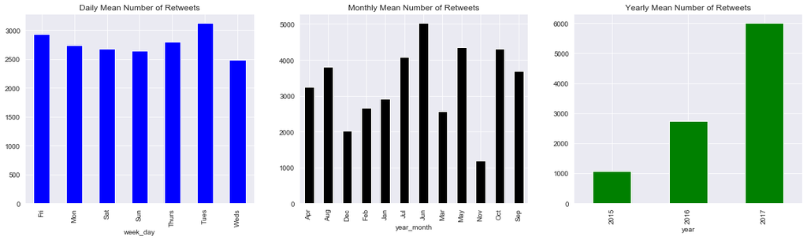

```python
# Visualization of Retweets 1
plt.figure(figsize=(20,5))
plt.subplot(1,3,1)
daily_retweet_mean.plot(kind='bar',color='b')
plt.title('Daily Mean Number of Retweets')
plt.subplot(1,3,2)
monthly_retweet_mean.plot(kind='bar',color='black')
plt.title('Monthly Mean Number of Retweets')
plt.subplot(1,3,3)
yearly_retweet_mean.plot(kind='bar',color='g')
plt.title('Yearly Mean Number of Retweets');
```

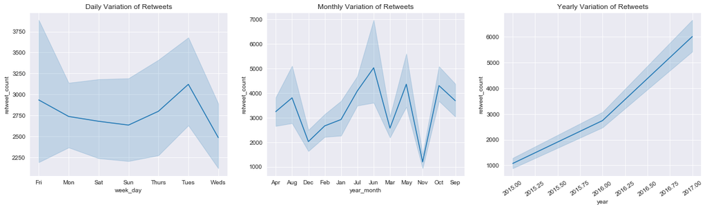

```python
# Visualization of retweets 2
plt.figure(figsize=(20,5))
plt.subplot(1,3,1)
sb.lineplot(y='retweet_count', x='week_day', data=df)
plt.title('Daily Variation of Retweets')
plt.subplot(1,3,2)
sb.lineplot(y='retweet_count', x='year_month', data=df)
plt.title('Monthly Variation of Retweets')
plt.subplot(1,3,3)
sb.lineplot(y='retweet_count', x='year', data=df)
plt.title('Yearly Variation of Retweets')
plt.xticks(rotation=35);
```

```python
# Visualizing favourites count
daily_favorite_mean = df.groupby('week_day')['favorite_count'].mean()
monthly_favorite_mean = df.groupby('year_month')['favorite_count'].mean()
yearly_favorite_mean = df.groupby('year')['favorite_count'].mean()
yearly_favorite_mean
```

```
year
2015     2492.277863
2016     7734.215707
2017    24072.076923
Name: favorite_count, dtype: float64
```

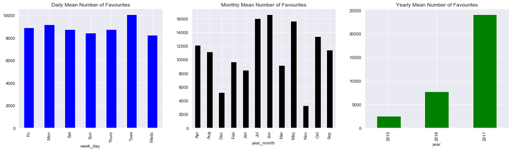

```python
# Visualization of Favourites 1
plt.figure(figsize=(20,5))
plt.subplot(1,3,1)
daily_favorite_mean.plot(kind='bar',color='b')
plt.title('Daily Mean Number of Favourites')
plt.subplot(1,3,2)
monthly_favorite_mean.plot(kind='bar',color='black')
plt.title('Monthly Mean Number of Favourites')
plt.subplot(1,3,3)
yearly_favorite_mean.plot(kind='bar',color='g')
plt.title('Yearly Mean Number of Favourites');
```

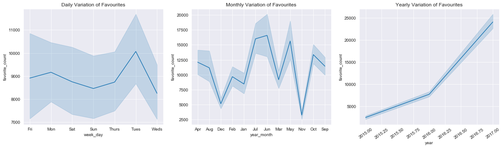

```python
# Visualization of retweets 2
plt.figure(figsize=(20,5))
plt.subplot(1,3,1)
sb.lineplot(y='favorite_count', x='week_day', data=df)
plt.title('Daily Variation of Favourites')
plt.subplot(1,3,2)
sb.lineplot(y='favorite_count', x='year_month', data=df)
plt.title('Monthly Variation of Favourites')
plt.subplot(1,3,3)
sb.lineplot(y='favorite_count', x='year', data=df)
plt.title('Yearly Variation of Favourites')
plt.xticks(rotation=35);
```

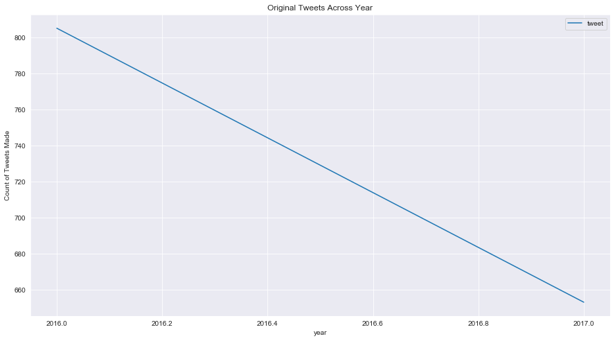

```python
# Checking yearly tweets overtime
df1 = df[['year', 'tweet']].groupby(['year']).count()
df1.tweet.nlargest(5)
# Use moving averages to smooth the line
df1['tweet'] = df1['tweet'].rolling(window=2).mean()
# Plot
df1.plot(figsize=(15, 8), title='Original Tweets Across Year')
plt.ylabel('Count of Tweets Made')
plt.savefig('yearly_tweets.png');
```

```python
# Tweets per year
df2 = df[['year', 'tweet']].groupby(['year']).count()
df2
```

| year | tweet |
| --- | --- |
| 2015 | 655 |
| 2016 | 955 |
| 2017 | 351 |

```python
# Retweets per year
df2 = df[['year', 'retweet_count']].groupby(['year']).sum()
df2
```

| year | retweet_count |
| --- | --- |
| 2015 | 705898 |
| 2016 | 2617771 |
| 2017 | 2106674 |

```python
# Favorites per year
df3 = df[['year', 'favorite_count']].groupby(['year']).sum()
df3
```

| year | favorite_count |
| --- | --- |
| 2015 | 1632442 |
| 2016 | 7386176 |
| 2017 | 8449299 |

> It can be seen that the pattern of favorite_count is similar to that of retweet_count across years, months, and days. With regards to original tweets, most tweets were made in 2016 and reduced drastically in 2017. But retweets were still substantial in 2017. Favourites were highest in 2017. This portrays that they keep digging the achhives and retweeting. Now on to the next question.

```python
# The breeds of dog are captured in name
df.name.value_counts().nlargest(12)
# Now I need to omit the Not Availables
```

```
Not_Available    519
A                 55
Charlie           11
Lucy              10
Oliver            10
Cooper            10
Penny              9
Tucker             9
Winston            8
Sadie              8
Daisy              7
Lola               7
Name: name, dtype: int64
```

```python
popular_dogs = df.name.value_counts().nlargest(12)[1:-1]
popular_dogs
# Since we have decided to leave such names as 'A', 'The', etc, then the ten most popular names
# are displayed below.
```

```
A          55
Charlie    11
Lucy       10
Oliver     10
Cooper     10
Penny       9
Tucker      9
Winston     8
Sadie       8
Daisy       7
Name: name, dtype: int64
```

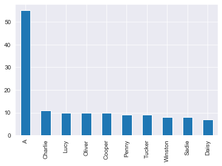

```python
popular_dogs.plot(kind='bar')
plt.savefig('popular_dogs_bar.png');
```

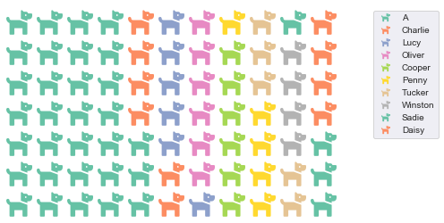

```python
# Making a waffle for it
fig = plt.figure(FigureClass = Waffle,
                rows= 7,
                columns = 11,
                values = list(popular_dogs.values),
                labels = list(popular_dogs.index),
                figsize=(7,6),
                icons = 'dog',
                icon_legend = True,
                legend = {'loc':'upper left',
                         'bbox_to_anchor':(1.1,1)})
plt.savefig('popular_dogs_waffle.png');
```

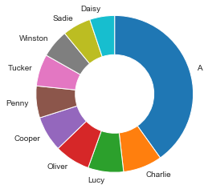

```python
# Making a donut to show popular_dogs
plt.pie(popular_dogs,labels=popular_dogs.index,startangle=90,counterclock=False,wedgeprops={'width':0.5})
plt.axis('square')
plt.savefig('popular_dogs_donut.png');
```

> As shown by the grouping, the bar chart, the Waffle plot,and the donut, the five most popular dog names are A, Charlie, Oliver, Cooper, and Lucy. Now, let us move on to the next question.

#### What are the most popular dog_stages?

```python
# Dog stages are captured in the dog_stage variable
df.dog_stage.value_counts()
```

```
Not_available    1668
Pupper            201
Doggo              63
Puppo              22
Floofer             7
Name: dog_stage, dtype: int64
```

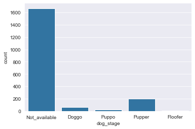

```python
# First view with the Not Availables
sb.countplot(df['dog_stage'], color= sb.color_palette()[0])
plt.savefig('dog_stage_bar.png');
```

```python
# Now I will remove the Not Availables
popular_dog_stage = df.dog_stage.value_counts()[1:]
popular_dog_stage
```

```
Pupper     201
Doggo       63
Puppo       22
Floofer      7
Name: dog_stage, dtype: int64
```

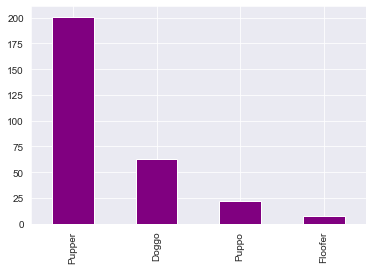

```python
# Now we visualize it in bars and waffle
popular_dog_stage.plot(kind='bar', color = 'purple')
plt.savefig('dog_stage_bar_ordered.png');
```

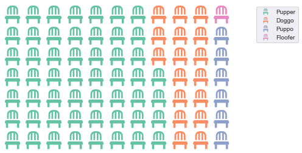

```python
# Making a waffle for it
fig = plt.figure(FigureClass = Waffle,
                rows= 7,
                columns = 11,
                values = list(popular_dog_stage.values),
                labels = list(popular_dog_stage.index),
                figsize=(7,6),
                icons = 'chair',
                icon_legend = True,
                legend = {'loc':'upper left',
                         'bbox_to_anchor':(1.1,1)});
plt.savefig('dog_stage_waffle.png');
```

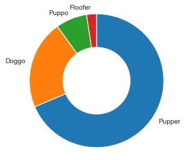

```python
# Making a donut to show popular_dog_stage
plt.pie(popular_dog_stage,labels=popular_dog_stage.index,startangle=90,counterclock=False,wedgeprops={'width':0.5})
plt.axis('square')
plt.savefig('dog_stage_donut.png');
```

> As shown by the grouping, the bar chart, the Waffle plot,and the donut, the most popular dog stage is Pupper followed by Doggo. Now, let us move on to the last question.

#### What variables affect rating?

```python
# First I will describe rating
df.rating.describe()
# Next I will categorize rating for visualizations by creating a performance column
```

```
count     1961.000000
mean       149.906561
std        525.556286
min          0.000000
25%        128.152461
50%        140.967707
75%        153.782953
max      22759.877075
Name: rating, dtype: float64
```

```python
bin_edges = [0.00,128.16,140.97,153.79,22759.88]
bin_names = ['fair','good','very_good','excellent']
df['performance'] = pd.cut(df['rating'], bin_edges, labels=bin_names)
```

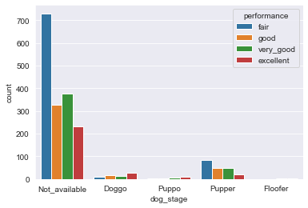

```python
# Visualizing dog_stage with performance
sb.countplot(data=df,x='dog_stage', hue='performance')
plt.savefig('dog_stage_performance.png');
```

```python
# Looking at the counts
df.groupby(['dog_stage','performance'])['performance'].count()
```

```
dog_stage      performance
Doggo          fair             9
               good            16
               very_good       12
               excellent       26
Floofer        fair             1
               good             1
               very_good        2
               excellent        3
Not_available  fair           730
               good           328
               very_good      378
               excellent      231
Pupper         fair            85
               good            49
               very_good       47
               excellent       20
Puppo          fair             4
               good             2
               very_good        6
               excellent       10
Name: performance, dtype: int64
```

```python
df.favorited.value_counts()
```

```
False    1956
True        5
Name: favorited, dtype: int64
```

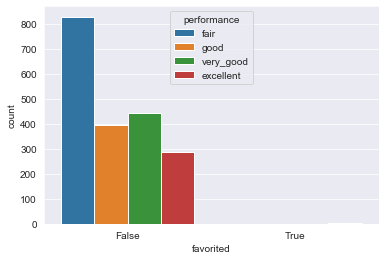

```python
# Visualizing dog_stage with performance
sb.countplot(data=df,x='favorited', hue='performance')
plt.savefig('favorited_performance.png');
```

```python
# Looking at the counts
df.groupby(['favorited','performance'])['performance'].count()
```

```
favorited  performance
False      fair           828
           good           395
           very_good      445
           excellent      287
True       fair             1
           good             1
           very_good        0
           excellent        3
Name: performance, dtype: int64
```

> Being favorited does not appear to have anything to do with high performance

```python
df.source.value_counts()
```

```
<a href="http://twitter.com/download/iphone" rel="nofollow">Twitter for iPhone</a>     1922
<a href="http://twitter.com" rel="nofollow">Twitter Web Client</a>                       28
<a href="https://about.twitter.com/products/tweetdeck" rel="nofollow">TweetDeck</a>      11
Name: source, dtype: int64
```

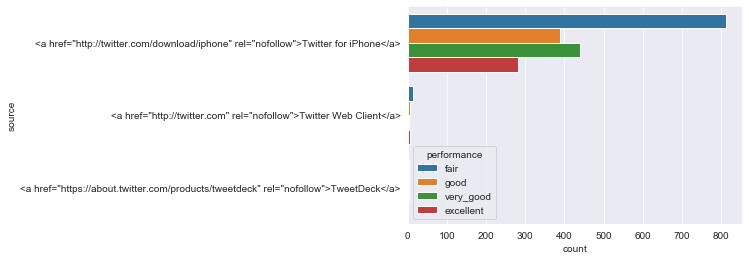

```python
# Visualizing dog_stage with performance
sb.countplot(data=df,y='source', hue='performance')
plt.savefig('source_performance.png');
```

```python
df.groupby(['source','performance'])['performance'].count()
```

```
source                                                                               performance
<a href="http://twitter.com" rel="nofollow">Twitter Web Client</a>                   fair            13
                                                                                     good             5
                                                                                     very_good        3
                                                                                     excellent        7
<a href="http://twitter.com/download/iphone" rel="nofollow">Twitter for iPhone</a>   fair           813
                                                                                     good           388
                                                                                     very_good      439
                                                                                     excellent      281
<a href="https://about.twitter.com/products/tweetdeck" rel="nofollow">TweetDeck</a>  fair             3
                                                                                     good             3
                                                                                     very_good        3
                                                                                     excellent        2
Name: performance, dtype: int64
```

> Although most tweets originate from *Twitter for iPhone* 25 percent of the tweets originating from *Twitter Web Client* has excellent rating. But it is difficult to conclude that high rating is associated with a platform.

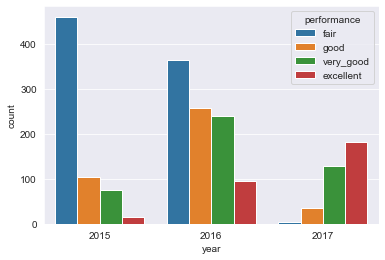

```python
# Visualizing dog_stage with performance
sb.countplot(data=df,x='year', hue='performance')
plt.savefig('year_performance.png');
```

> In 2015, a great percentage of the ratings are fair but this reduced in 2016 and it is barely existent in 2017. Could we say dogs became better, or WeRateDogs became smarter in rating?

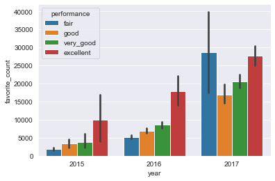

```python
sb.barplot(data=df,x='year', y='favorite_count', hue='performance')
plt.savefig('year_favorite_count_performance.png');
```

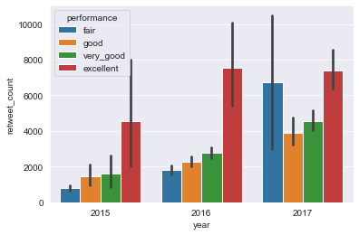

```python
sb.barplot(data=df,x='year', y='retweet_count', hue='performance')
plt.savefig('year_retweet_count_performance.png');
```

## Limitations of the Analysis

> The major limitation of this analysis is the inconsistencies across the different datasets. These necessitated different set of cleanings that resulted in losing some data points. Moreover, I did not do much analysis on the image aspect. Were the data points to be included, the results may be slightly impacted. Another limitation is my current skill level. It is still highly rudimentary.

## Bibliograpphy

> - https://www.datacamp.com/
> - https://seaborn.pydata.org/controlling-figure-asthetics
> - https://stackoverflow.com/questions/25707558/json-valueerror-expecting-property-name-line-1-column-2-char-1
> - https://docs.python.org/3/library/json.html#json.loads
> - http://www.jeannicholashould.com/tidy-data-in-python.html
> - https://developer.twitter.com/en/docs/tweets/post-and-engage/api-reference/get-statuses-show-id.html
> - https://developer.twitter.com/en/docs/tweets/data-dictionary/overview/tweet-object.html
> - https://developer.twitter.com/en/docs/tweets/data-dictionary/overview/user-object
> - https://media.readthedocs.org/pdf/tweepy/latest/tweepy.pdf
> - https://stackabuse.com/reading-and-writing-json-to-a-file-in-python/

```python
# Saving the little adjustments in the initial master csv
df.to_csv('final_werate.csv', index=False)
```